https://www.r-bloggers.com/simple-steps-to-create-treemap-in-r/

# Treemaps in R

using the treemap package.

What are they & when do we use them

In the most basic terms a treemap is generally used when we want to visualize proportions. It can be thought of a pie map where the slices are replaced by rectangles. Using pie charts to visualize proportion is an excellent way, however if the categories keep on increasing the pie charts tends to become more and more unreadable. This issue of pie charts is overcomed in a Treemap which uses nested structure. These are ideal for displaying large amount of hierarchical data. We can use a treemap when space is a constraint and we have a large amount of hierarchical data to get an overview.

A treemap is a diagram representing hierarchical data in the form of nested rectangles, the area of each corresponding to its numerical value

When not to use a treemap

A treemap should not be used when there is a big difference between the measure values or the values are not comparable. Also, negative values cannot be displayed on a treemap.

Building a Treemap in R

To create a treemap we use one or more dimension and a maximum of 2 measures. We will be using the treemap package in R. For this article we will use the Super Store data which is provided along with the article.

Step 1: Importing Data and installing treemap package in R

```r
library(tidyverse)
library(readxl)
## Import the datafile in R and view the data sample)
myfile<-"./data/Sample-Superstore.xls"
data= read_excel(myfile, sheet = NULL, skip=3)

summary(data)
```

```
     Row ID       Order ID           Order Date
 Min.   :   1   Length:9994        Min.   :2013-01-03 00:00:00
 1st Qu.:2499   Class :character   1st Qu.:2014-05-23 00:00:00
 Median :4998   Mode  :character   Median :2015-06-27 00:00:00
 Mean   :4998                      Mean   :2015-05-01 00:07:12
 3rd Qu.:7496                      3rd Qu.:2016-05-14 00:00:00
 Max.   :9994                      Max.   :2016-12-30 00:00:00
   Ship Date                    Ship Mode         Customer ID
 Min.   :2013-01-07 00:00:00   Length:9994        Length:9994
 1st Qu.:2014-05-27 00:00:00   Class :character   Class :character
 Median :2015-06-30 00:00:00   Mode  :character   Mode  :character
 Mean   :2015-05-04 23:06:58
 3rd Qu.:2016-05-18 00:00:00
 Max.   :2017-01-05 00:00:00
 Customer Name        Segment            Country              City
 Length:9994        Length:9994        Length:9994        Length:9994
 Class :character   Class :character   Class :character   Class :character
 Mode  :character   Mode  :character   Mode  :character   Mode  :character



    State            Postal Code       Region           Product ID
 Length:9994        Min.   : 1040   Length:9994        Length:9994
 Class :character   1st Qu.:23223   Class :character   Class :character
 Mode  :character   Median :56430   Mode  :character   Mode  :character
                    Mean   :55190
                    3rd Qu.:90008
                    Max.   :99301
   Category         Sub-Category       Product Name           Sales
 Length:9994        Length:9994        Length:9994        Min.   :    0.444
 Class :character   Class :character   Class :character   1st Qu.:   17.280
 Mode  :character   Mode  :character   Mode  :character   Median :   54.490
                                                          Mean   :  229.858
                                                          3rd Qu.:  209.940
                                                          Max.   :22638.480
    Quantity        Discount          Profit
 Min.   : 1.00   Min.   :0.0000   Min.   :-6599.978
 1st Qu.: 2.00   1st Qu.:0.0000   1st Qu.:    1.729
 Median : 3.00   Median :0.2000   Median :    8.666
 Mean   : 3.79   Mean   :0.1562   Mean   :   28.657
 3rd Qu.: 5.00   3rd Qu.:0.2000   3rd Qu.:   29.364
 Max.   :14.00   Max.   :0.8000   Max.   : 8399.976
```

Once we get the data in R we need to load the package treemap so that we can go ahead creating our required plot.

```r
## Installing the package and calling the package in R##
install.packages("treemap")
library(treemap)
```

The data that we are using is already reshaped data and so we can go ahead with creating our basic treemap and move step by step from it.

Step 2: Creating a Treemap

The treemap function is used to create a treemap.

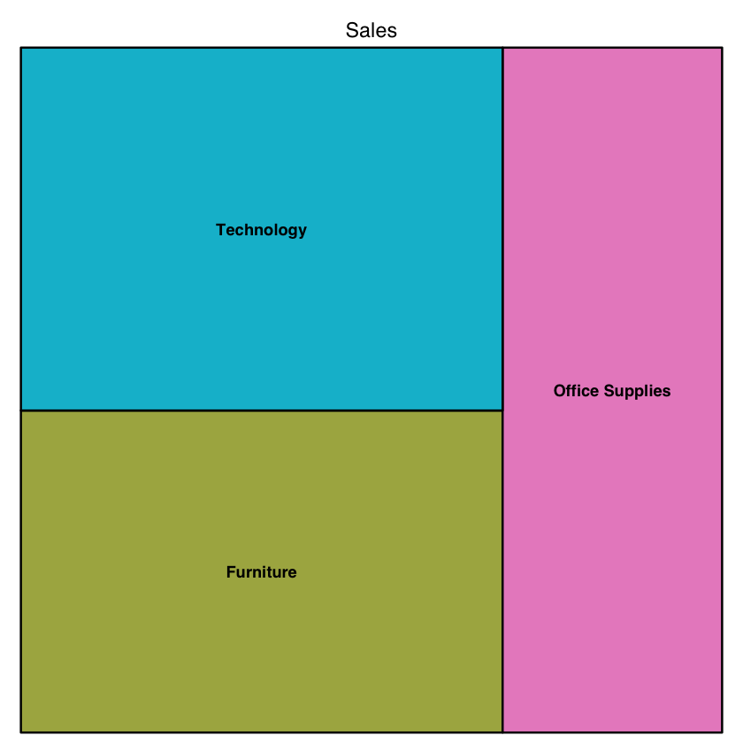

```r
## Creating the most basic treemap##
treemap(data,index = c("Category"),vSize ="Sales")
```

The first argument in the above formula is the data file name which is “data” in our case. The arguments within the index specify the hierarchy that we are looking into and the argument vSize tell R to pick up a values on which the proportion of the boxes are to be decided. In our case since we have only index in our formula the command just splits the entire tree in three parts ( each representing the proportion of Sales for these part) A first look into the above figures shows that the Proportion of Technology, Furniture and Office Supplies is almost within the same range , the highest being technology.

We can check our hunch right away, Type in the following :

```r
aggregate(Sales ~ Category, data, sum)
```

A data.frame: 3 × 2

| Category <chr> | Sales <dbl> |
| --- | --- |
| Furniture | 741999.8 |
| Office Supplies | 719047.0 |
| Technology | 836154.0 |

We see how close these Sales are to other (proportionately)

Now as we have created our most basic treemap lets go a bit further and see what happens when we list multiple values in the index ( create a hierarchy )

Creating a treemap with Category and Subcategory as a hierarchy.

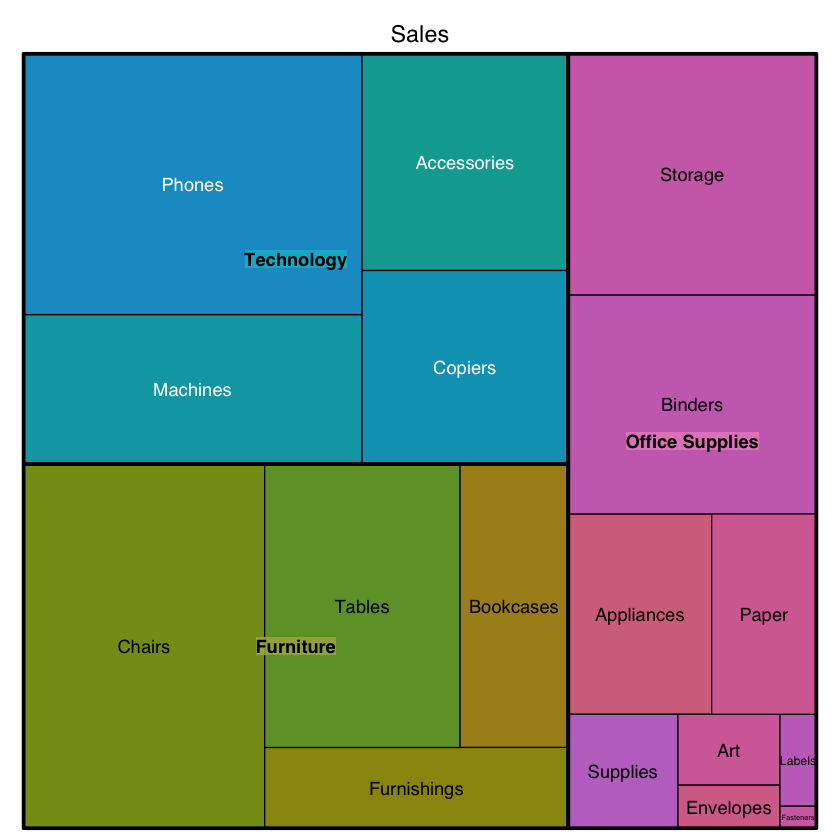

```r
treemap(data,index = c("Category","Sub-Category"),vSize = "Sales")
```

Here is what happened, the tree is first splits at the category level and then each category further splits under a subcategory. We can see from the treemap that the Technology Category accounted for maximum sales and within the Technology category, Phones accounted for most of the sales. (the size of the boxes are still by Sales)

Let’s go a step further and color the boxes by another measure let’s say profit.